# Genome-wide methylation analysis report

# Genome-wide methylation analysis report

- study: Pleural cfDNAm analysis of phvariable
- author: Paul Yousefi
- date: 08 October, 2026

## Parameters

```
## $sig.threshold
## [1] 2.121143e-07
##
## $max.plots
## [1] 10
##
## $qq.inflation.method
## [1] "median"
##
## $practical.threshold
## [1] 0.0002133738
```

## Sample characteristics

For continuous or ordinal variables, the “mean” column provides the mean and the “sd/%” column the standard deviation of the variable. For categorical variables, the “mean” column provides the number of samples with the given “value” and the “sd/%” column the percentage of samples with the given “value”.

| variable | value | mean | sd.. |
| --- | --- | --- | --- |
| ph |  | 7.443586 | 0.1814192 |
| sv1 |  | -2.458897e-20 | 0.06509446 |
| sv2 |  | 3.544243e-19 | 0.06509446 |
| sv3 |  | 2.314165e-18 | 0.06509446 |
| sv4 |  | -1.5421e-19 | 0.06509446 |
| sv5 |  | -9.113074e-19 | 0.06509446 |
| sv6 |  | -3.006974e-18 | 0.06509446 |
| sv7 |  | -3.95282e-19 | 0.06509446 |
| sv8 |  | 2.760119e-18 | 0.06509446 |
| sv9 |  | 3.835372e-18 | 0.06509446 |
| sv10 |  | 5.872491e-16 | 0.06509446 |

## Covariate associations

### Covariate sv1

statistics

| var1 | var2 | F | p-value | R | p-value |
| --- | --- | --- | --- | --- | --- |
| ph | sv1 | 0.2502366 | 0.6173767 | 0.0341581 | 0.6008148 |

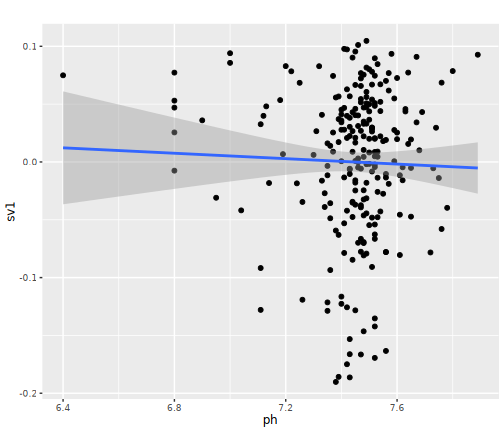

### Covariate sv2

statistics

| var1 | var2 | F | p-value | R | p-value |
| --- | --- | --- | --- | --- | --- |
| ph | sv2 | 0.7876172 | 0.375729 | 0.0856802 | 0.1886865 |

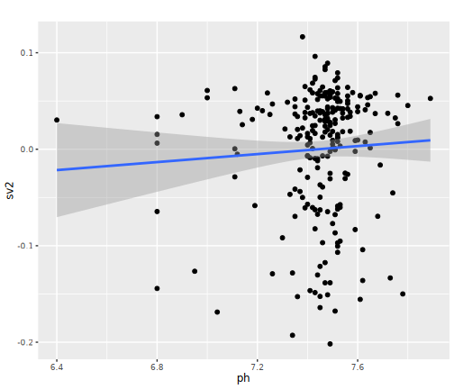

### Covariate sv3

statistics

| var1 | var2 | F | p-value | R | p-value |
| --- | --- | --- | --- | --- | --- |
| ph | sv3 | 2.432091 | 0.1202199 | 0.1678244 | 0.0096438 |

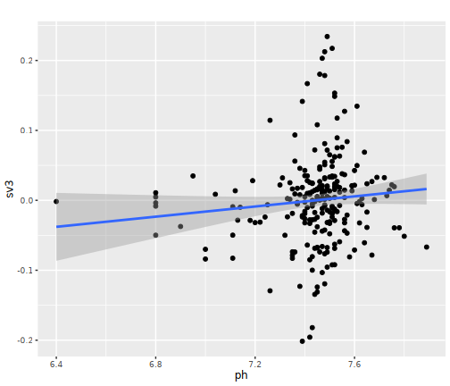

### Covariate sv4

statistics

| var1 | var2 | F | p-value | R | p-value |
| --- | --- | --- | --- | --- | --- |
| ph | sv4 | 0.2216603 | 0.6382145 | 0.0444735 | 0.4956322 |

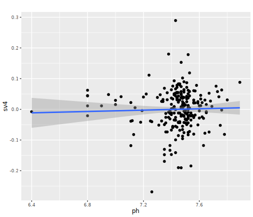

### Covariate sv5

statistics

| var1 | var2 | F | p-value | R | p-value |
| --- | --- | --- | --- | --- | --- |
| ph | sv5 | 0.0229279 | 0.8797745 | 0.0261961 | 0.6882579 |

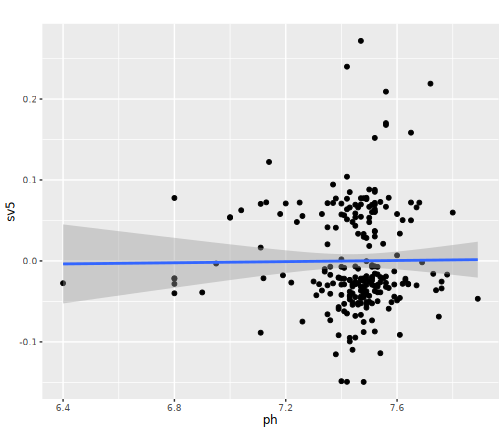

### Covariate sv6

statistics

| var1 | var2 | F | p-value | R | p-value |
| --- | --- | --- | --- | --- | --- |
| ph | sv6 | 0.055999 | 0.8131414 | 0.0107696 | 0.8690035 |

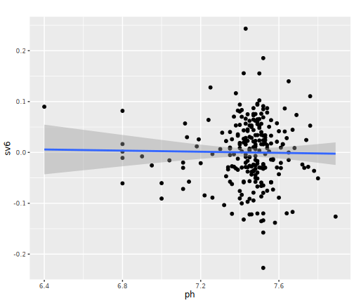

### Covariate sv7

statistics

| var1 | var2 | F | p-value | R | p-value |
| --- | --- | --- | --- | --- | --- |
| ph | sv7 | 0.0290731 | 0.8647571 | 0.0073017 | 0.9109701 |

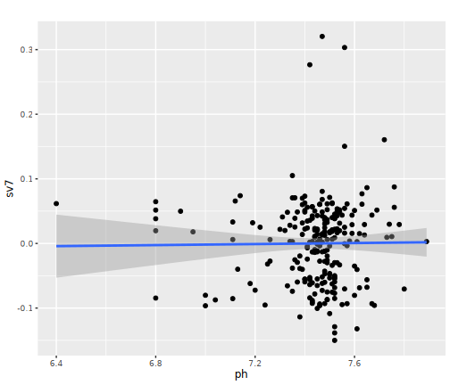

### Covariate sv8

statistics

| var1 | var2 | F | p-value | R | p-value |
| --- | --- | --- | --- | --- | --- |
| ph | sv8 | 0.0991594 | 0.7531201 | -0.0587386 | 0.367979 |

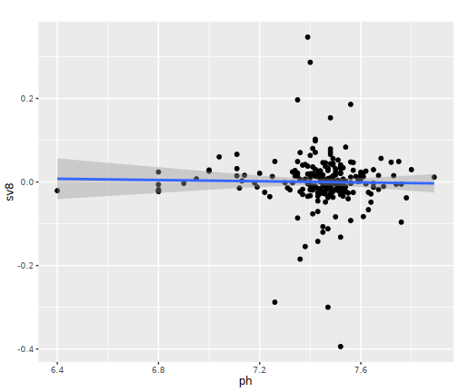

### Covariate sv9

statistics

| var1 | var2 | F | p-value | R | p-value |
| --- | --- | --- | --- | --- | --- |
| ph | sv9 | 0.0529975 | 0.8181273 | -0.0264721 | 0.6851472 |

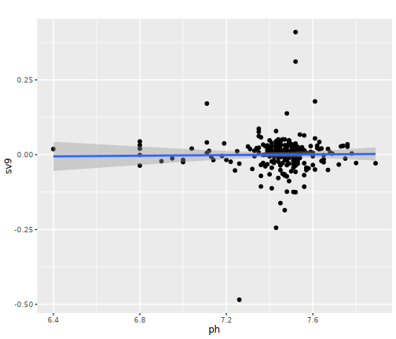

### Covariate sv10

statistics

| var1 | var2 | F | p-value | R | p-value |
| --- | --- | --- | --- | --- | --- |
| ph | sv10 | 0.0225071 | 0.8808747 | 0.0262398 | 0.6877645 |

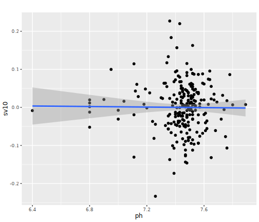

## QQ plots

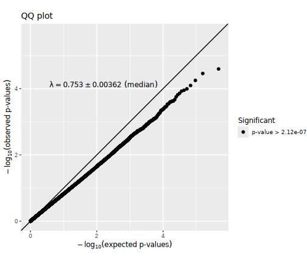

## Manhattan plots

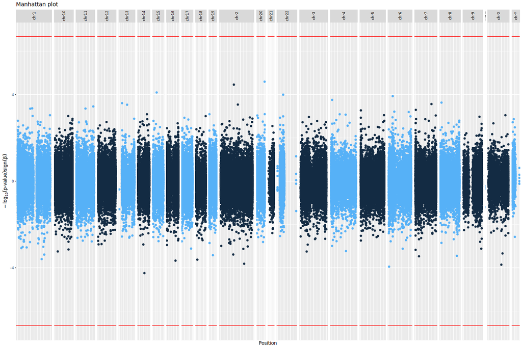

## Significant CpG sites

There were 0 CpG sites with association p-values < 2.1211427 × 10<sup>-7</sup>. These are listed in the file associations.csv.

Below are the 10 CpG sites with association p-values < 2.1337382 × 10<sup>-4</sup> in the regression model.

|  | chromosome | position | estimate | p.value | p.adjust |
| --- | --- | --- | --- | --- | --- |
| cg26401018 | chr22 | 42971631 | 0.0816703 | 0.0001015 | 1 |
| cg25535698 | chr20 | 60800277 | 0.1241968 | 0.0000255 | 1 |
| cg02705759 | chr4 | 7283005 | 0.1359785 | 0.0001768 | 1 |
| cg20374349 | chr15 | 50541593 | 0.1549413 | 0.0000804 | 1 |
| cg03858745 | chr2 | 179399147 | -0.0956913 | 0.0001529 | 1 |
| cg03213487 | chr2 | 100404536 | 0.1273821 | 0.0000349 | 1 |
| cg27361814 | chrX | 100074568 | -0.2113366 | 0.0001384 | 1 |
| cg19637866 | chr14 | 69106301 | -0.1266674 | 0.0000565 | 1 |
| cg09351698 | chr6 | 30453713 | 0.1916599 | 0.0001189 | 1 |
| cg26893685 | chr6 | 2523615 | -0.1756046 | 0.0001118 | 1 |

Plots of these sites follow, one for each covariate set. “p[lm]” denotes the p-value obtained using a linear model and “p[beta]” the p-value obtained using beta regression.

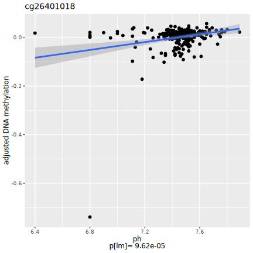

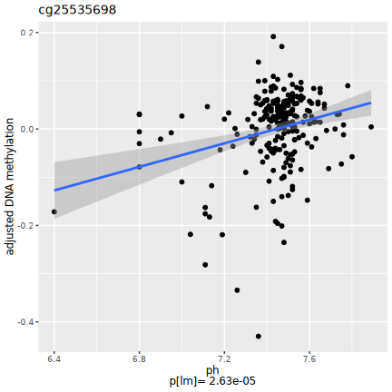

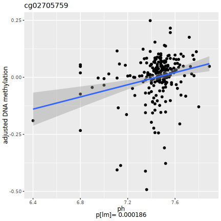

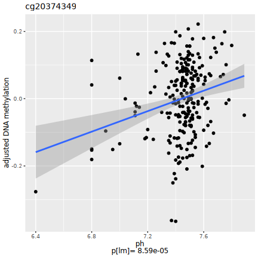

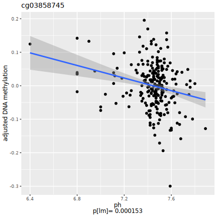

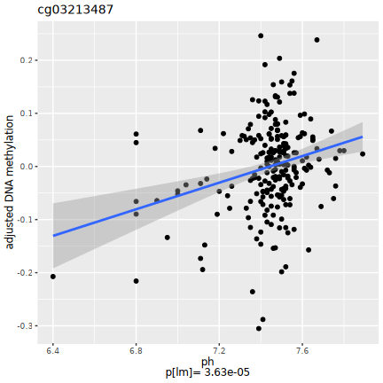

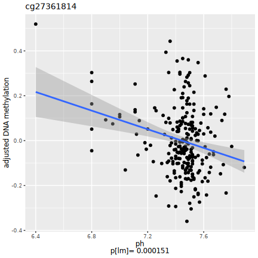

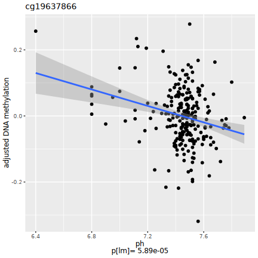

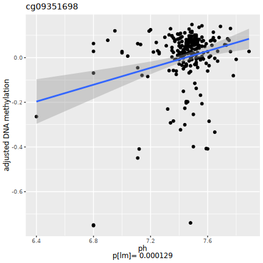

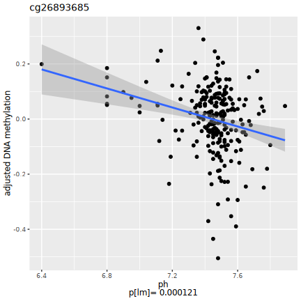

## Selected CpG sites

Number of CpG sites selected: 0.

| chromosome | position | estimate | p.value | p.adjust |
| --- | --- | --- | --- | --- |